### 0.15.2 check overlap of replicates

Perfect overlap between replicates… very suspicious

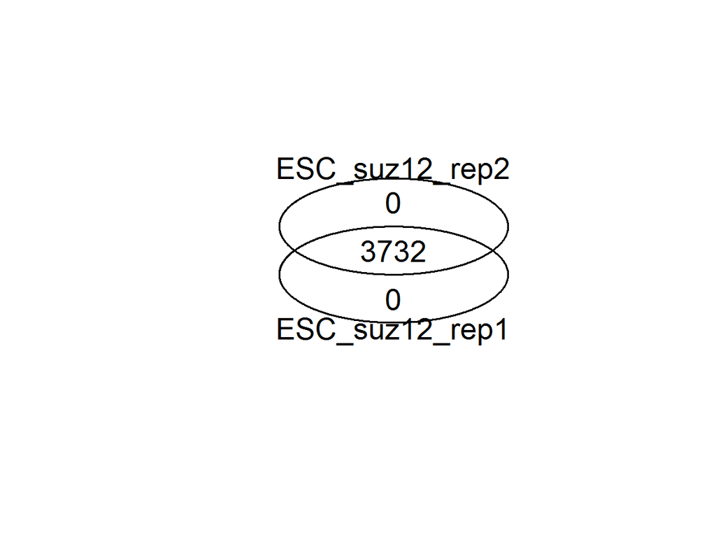

```r
venn(chipseq_bed_promoter_overlap[c("ESC_suz12_rep1","ESC_suz12_rep2")])
```

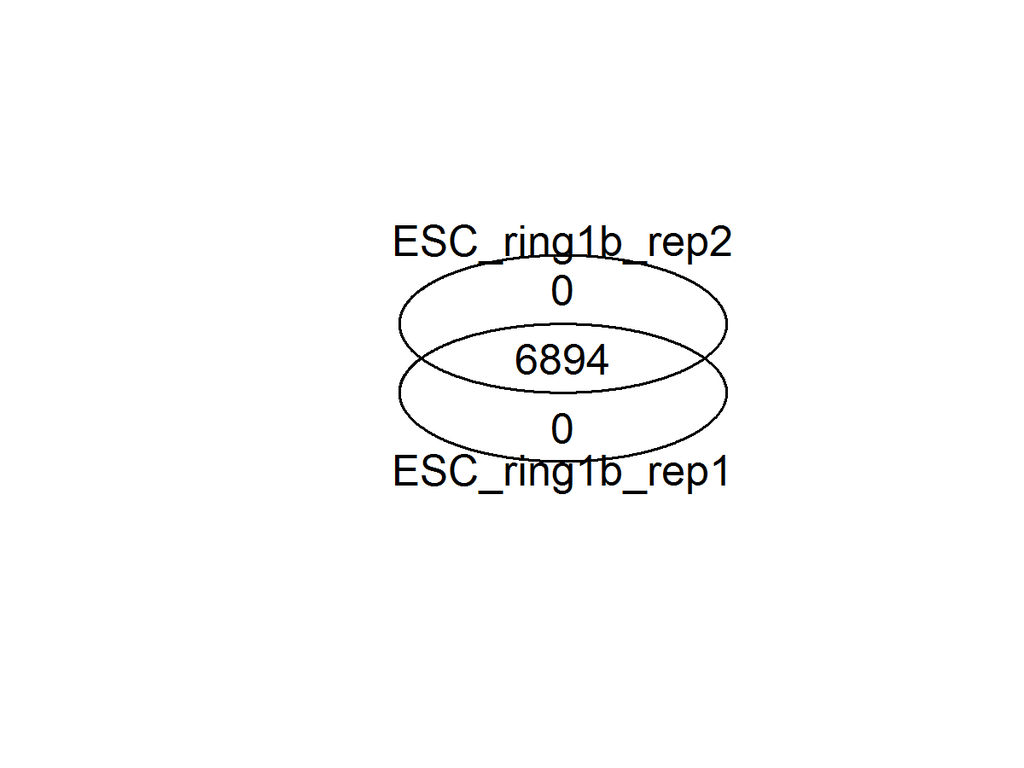

```r
venn(chipseq_bed_promoter_overlap[c("ESC_ring1b_rep1","ESC_ring1b_rep2")])
```

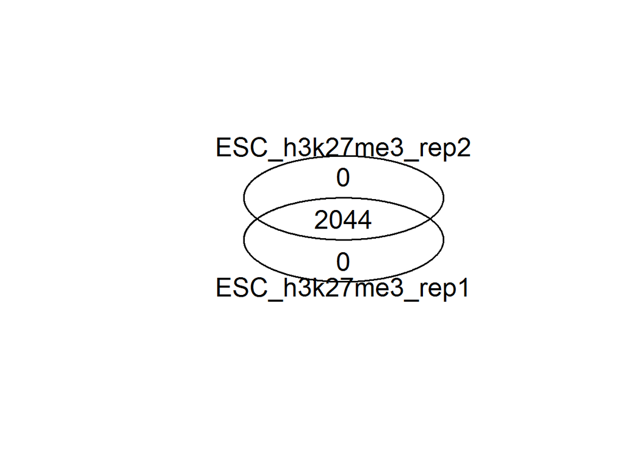

```r
venn(chipseq_bed_promoter_overlap[c("ESC_h3k27me3_rep1","ESC_h3k27me3_rep2")])
```

```r
es_bivalent <- venn_with_pval(chipseq_bed_promoter_overlap$ESC_ES_bivalent_rep1, chipseq_bed_promoter_overlap$ESC_ES_bivalent_rep2, test_name = "bivalent_rep1", reference_name = "bivalent_rep2", return_all = T) %>% unlist
```

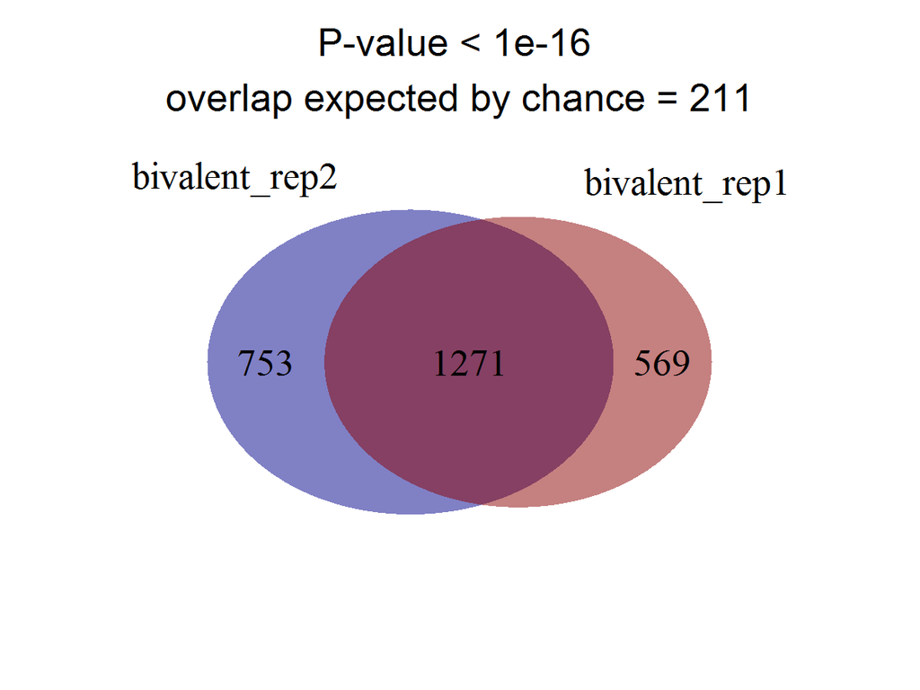

Well, except bivalent promoters. Will use the union to increase sensitivity

### 0.15.3 check overlap of PRC2 components

- Consider PRC2 target if at least 2 components mark it

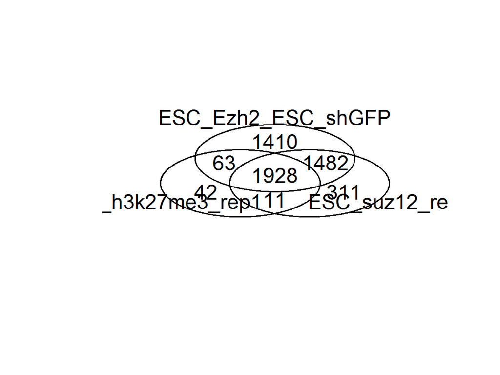

```r
x <- venn(chipseq_bed_promoter_overlap[c("ESC_h3k27me3_rep1","ESC_suz12_rep1","ESC_Ezh2_ESC_shGFP")])
```

```r
prc2_targets <- attr(x, "intersections") %>% .[grepl("\\:", names(.))] %>% unlist %>% unname
```

### 0.15.4 check overlap of PRC2 and PRC1

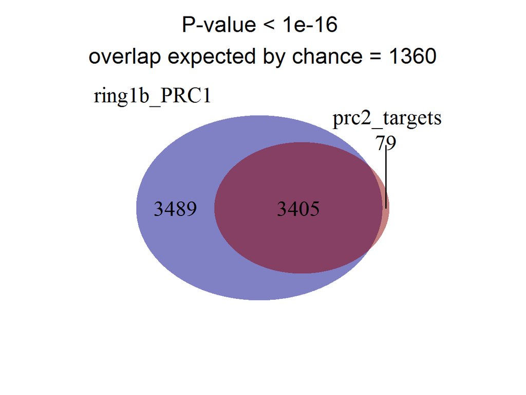

```r
venn_with_pval(test = prc2_targets, reference = chipseq_bed_promoter_overlap$ESC_ring1b_rep1, reference_name = "ring1b_PRC1")
```

## 0.16 Effects of Dnmt3l or PRC2 knockdown on the other

### 0.16.1 compare effect of dnmt3L KD on Ezh2 binding

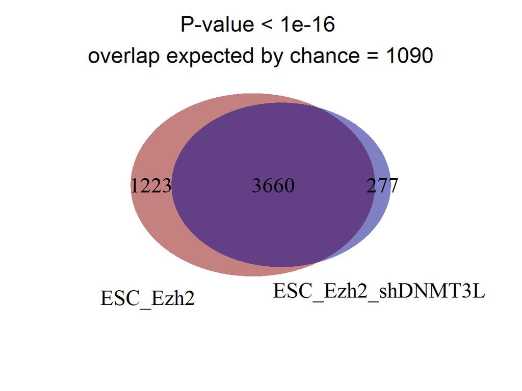

```r
# venn(chipseq_bed_promoter_overlap[c(1:2)])
venn_with_pval(chipseq_bed_promoter_overlap$ESC_Ezh2_ESC_shGFP, chipseq_bed_promoter_overlap$ESC_Ezh2_ESC_shDnmt3L, test_name = "ESC_Ezh2", reference_name = "ESC_Ezh2_shDNMT3L")
```

### 0.16.2 compare effect of Suz12 kd on DNMT3L binding

Roughly half of WT DNDMT3L peaks are lost upon Suz12 KD

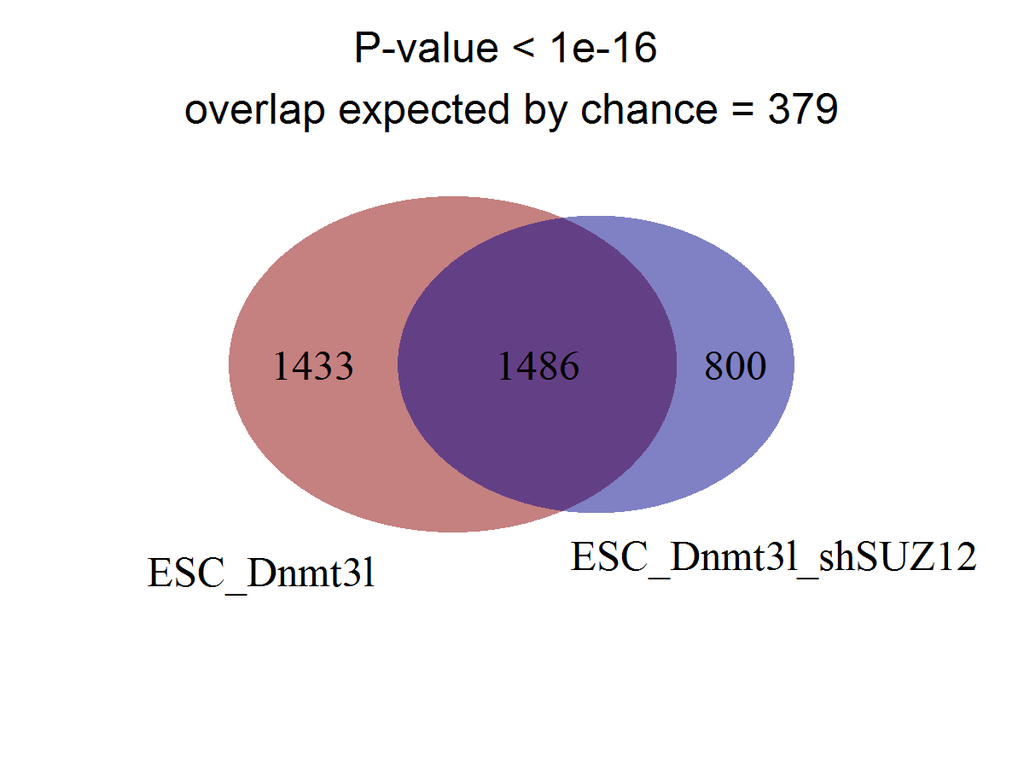

```r
# venn(chipseq_bed_promoter_overlap[c(3:4)])
venn_with_pval(test = chipseq_bed_promoter_overlap$ESC_BioDnmt3L_ESC_shGFP, reference = chipseq_bed_promoter_overlap$ESC_BioDnmt3L_ESC_shSuz12, test_name = "ESC_Dnmt3l", reference_name = "ESC_Dnmt3l_shSUZ12")
```

## 0.17 Genes bound by DNMT3L and PRC2

Consider peaks bound by DNMT3L and PRC2 targets

```r
prc2_dnmt3l_binding_promoters <- venn_with_pval(test = prc2_targets, reference = chipseq_bed_promoter_overlap$ESC_BioDnmt3L_ESC_shGFP, reference_name = "dnmt3l_shGFP", return_overlap = T)
```

- Add in SetDB1

*data obtained from supplemental table 8 from http://genesdev.cshlp.org/content/23/21/2484/suppl/DC2*

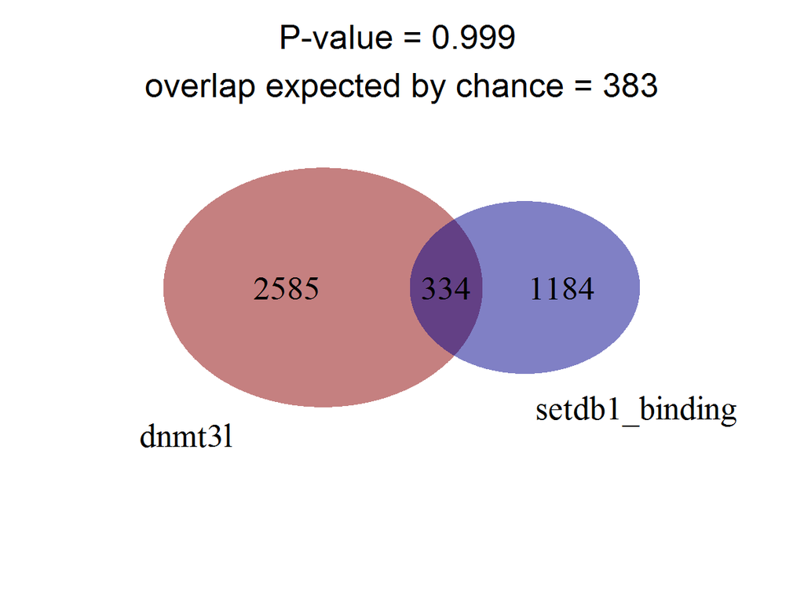

```r
setdb1_binding <- read.table("setdb1_mm9_ESC.bed") %>% setnames(c("chr", "start", "end")) %>% makeGRangesFromDataFrame() %>% subsetByOverlaps(query = refseq, subject = .) %>% .$gene_name
#
# venn(list(
#   prc2_targets = prc2_targets,
#   dnmt3l = chipseq_bed_promoter_overlap$ESC_BioDnmt3L_ESC_shGFP,
#   setdb1 = setdb1_binding
# ))

venn_with_pval(test = chipseq_bed_promoter_overlap$ESC_BioDnmt3L_ESC_shGFP, reference = setdb1_binding, test_name = "dnmt3l")
```

Total 1483 genes

- overlap with differentially expressed gene list

```r
candidate_list <- venn_with_pval(test = higher_in_old, reference = prc2_dnmt3l_binding_promoters, reference_name = "PRC2 Dnmt3l\nco-bound", return_overlap = T)
```

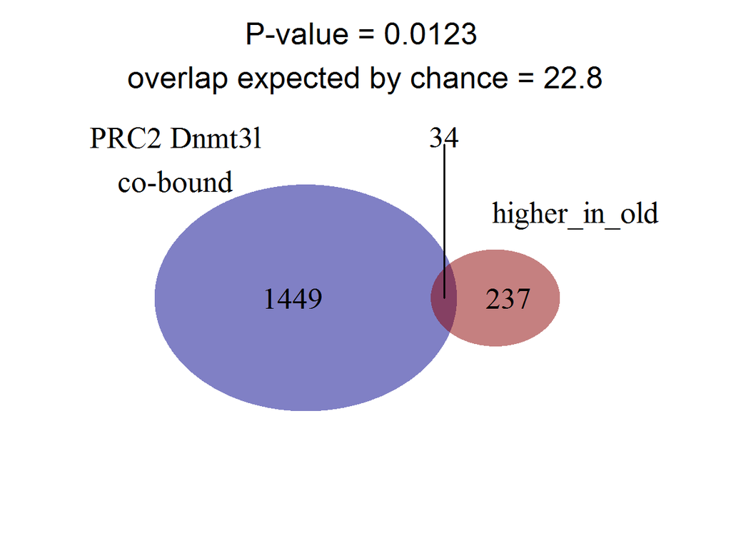

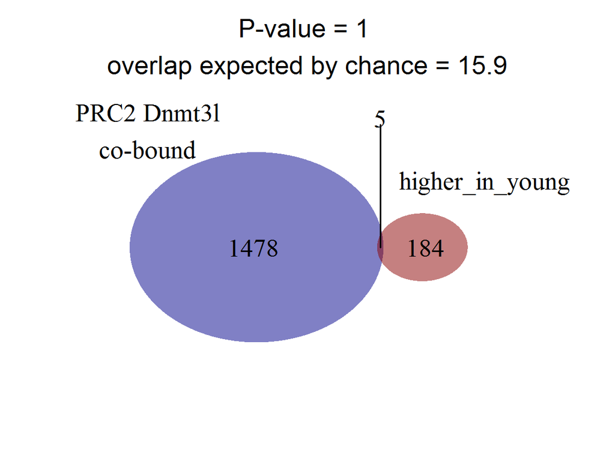

```
## [1] "Enpp1"  "Gdnf"   "Igfbp5" "Osmr"   "Ptgis"
```

```r
venn_with_pval(test = higher_in_young, reference = prc2_dnmt3l_binding_promoters, reference_name = "PRC2 Dnmt3l\nco-bound", return_overlap = T)
```

## 0.18 Validate that MEFs also contain prc2 at the promoters

```r
names <- dir("dnmt_chipseq/", "*", full.names = T) %>% grep(pattern = "mef_|ENCODE", x = ., value = T)

mef_chipseq <- lapply(names, function(x) {
  read.table(x, stringsAsFactors = F) %>% select(chr = V1, start = V2, end = V3) %>% makeGRangesFromDataFrame(keep.extra.columns = T)
  })

names(mef_chipseq) <- names %>% basename() %>% gsub("\\..*", "", .)

mef_chipseq_promoter_overlap <- lapply(mef_chipseq, function(x) find_overlapping_promoters(x) %>% .$gene_name %>% unique())
```

### 0.18.1 Overlap between Suz12 and h3k27me3 in MEFs

- treat prc2 targets as the intersect

```r
mef_prc2 <- venn_with_pval(test = mef_chipseq_promoter_overlap$mef_h3k27me3, reference = mef_chipseq_promoter_overlap$mef_suz12, test_name = "mef_h3k27me3", reference_name = "mef_suz12", return_overlap = T)
```

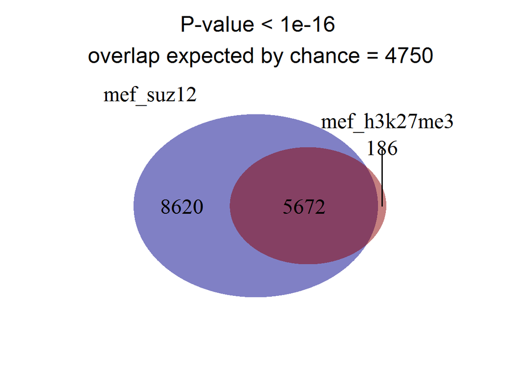

### 0.18.2 Overlap with ESC PRC2 targets

- not bad overlap

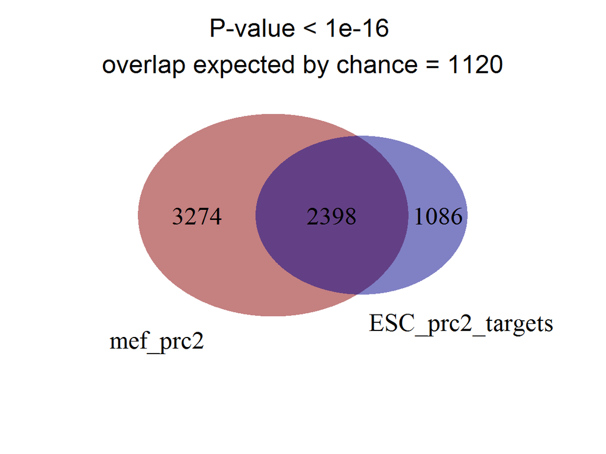

```r
venn_with_pval(test = mef_prc2, reference = prc2_targets, reference_name = "ESC_prc2_targets")
```

### 0.18.3 Overlap with ESC dnmt3l targets

- not bad overlap

```r
mef_prc2_dnmt3l <- venn_with_pval(test = mef_prc2, reference = chipseq_bed_promoter_overlap$ESC_BioDnmt3L_ESC_shGFP, reference_name = "ESC_dnmt3l", return_overlap = T)
```

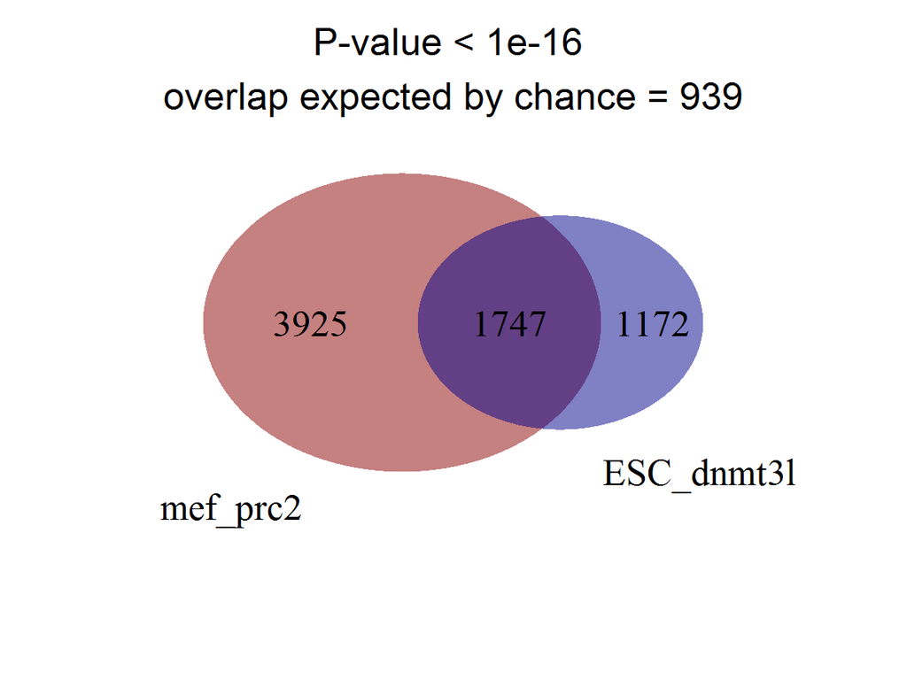

### 0.18.4 Quickly check all genes with MEF prc2

```r
mef_prc2_dnmt3_genes <- venn_with_pval(mef_prc2_dnmt3l, higher_in_old, return_overlap = T)
```

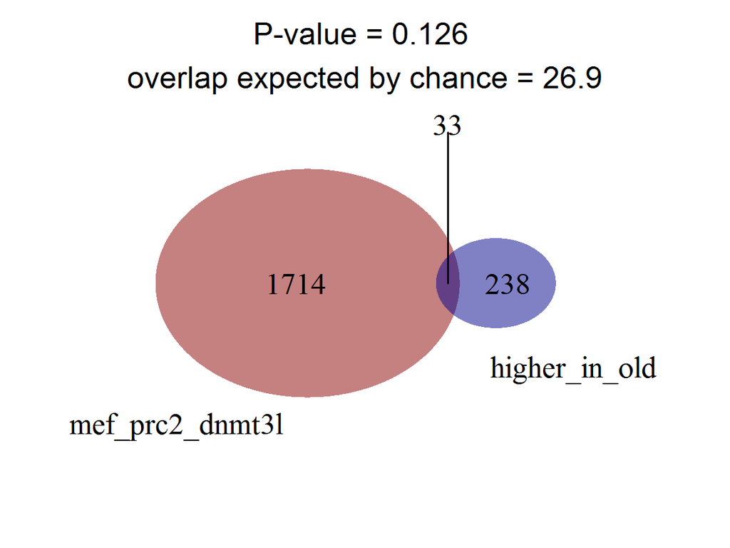

### 0.18.5 Overlap of candidate senescence genes with MEF prc2

```r
final_cand_list <- venn_with_pval(test = candidate_list, mef_prc2, return_overlap = T)
```

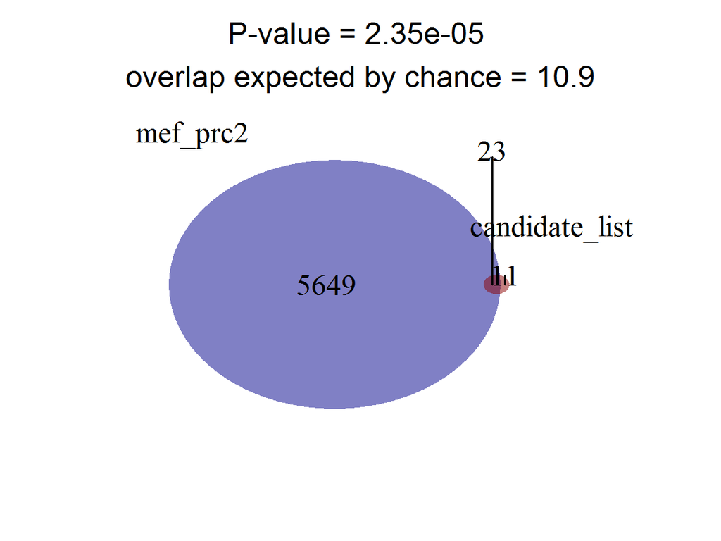

```r
failed<-candidate_list %>% .[!. %in% final_cand_list]
```

*Genes bound by DNMT3L, PRC2 in ESC, and PRC2 in MEF*: Ica1l, Dsp, 6030419C18Rik, Parm1, Adssl1, Aplp1, Fam155a, Gldn, Dnajc6, Dpysl4, Dusp15, Efna3, Espn, Kcnj4, Mmp15, Msx2, Satb1, Sim2, Sort1, Stau2, Tbc1d8, Tmeff2, Zdhhc14

*Genes bound by DNMT3L, PRC2 in ESC, but **not** PRC2 in MEF*: Adam15, Dpysl3, Dst, Hoxa2, Hoxa5, Hoxb4, Hoxb5, Hoxb6, Hoxb7, Oaf, Pon2

## 0.19 Methylation of promoters

### 0.19.1 Methylation of ES cells at Dnmt3L and Prc2 co-complexes

```r
x <- venn_with_pval(test = prc2_targets, reference = chipseq_bed_promoter_overlap$ESC_BioDnmt3L_ESC_shGFP, reference_name = "dnmt3l_shGFP", return_all = T)
```

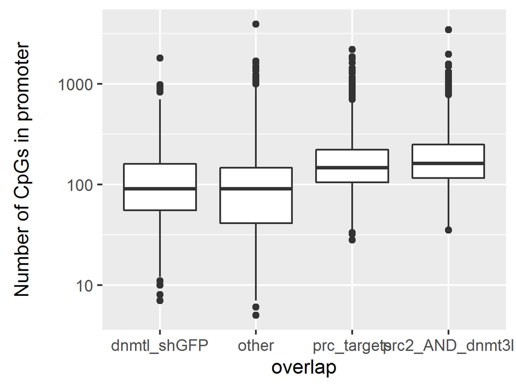

```r
x <- unlist(x) %>% as.data.frame %>% setnames("gene_name") %>%
  mutate(overlap = rownames(.) %>% gsub("[0-9]{1-3}", "", .) %>% as.character(),
         overlap = ifelse(grepl("\\:", overlap), "prc2_AND_dnmt3l", overlap))

left_join(esc_meth_overlaps, x) %>%
  # filter(!is.na(overlap)) %>%
  mutate(overlap = ifelse(is.na(overlap), "other", overlap)) %>%
  ggplot(aes(x = overlap, y = n_cpg)) +
  scale_y_log10() +
  ylab("Number of CpGs in promoter\n") +
  geom_boxplot()
```

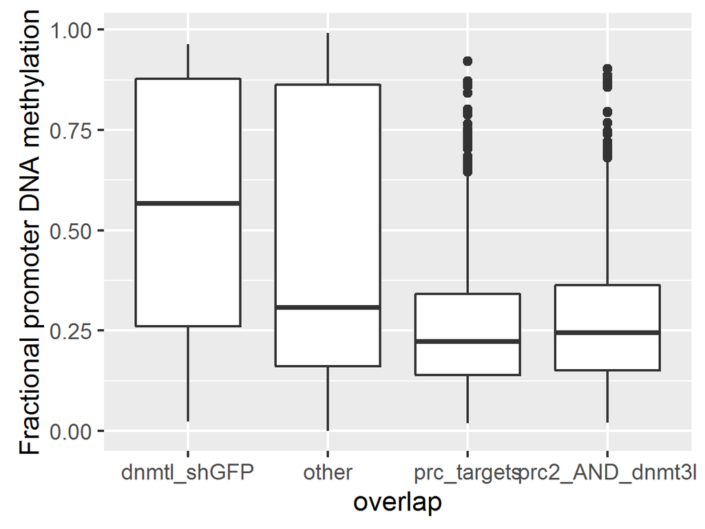

```r
left_join(esc_meth_overlaps, x) %>%
  # filter(!is.na(overlap)) %>%
  mutate(overlap = ifelse(is.na(overlap), "other", overlap)) %>%
  ggplot(aes(x = overlap, y = meth)) +
  ylab("Fractional promoter DNA methylation") +
  geom_boxplot()
```

### 0.19.2 See overlap of Fbxl10

- AKA Kdm2b, supposedly protects PRC genes from methylation http://www.ncbi.nlm.nih.gov/pubmed/25848754

```r
check_gene(gene = grep("Kdm2b", gene_info$gene_name, value = T), diff = F)
```

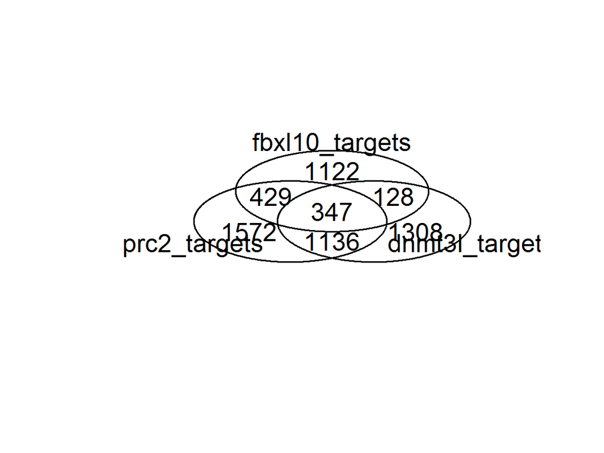

```r
fbxl10 <- lapply(dir(pattern = "targets.csv"), read.csv, skip = 1, stringsAsFactors=F)[[1]] %>% .$gene %>% subset(. %in% gene_info$gene_name)

x <- venn(list(
  prc2_targets = prc2_targets,
  dnmt3l_targets = chipseq_bed_promoter_overlap$ESC_BioDnmt3L_ESC_shGFP,
  fbxl10_targets = fbxl10
))
```

```r
y <- attr(x, "intersections")

overlaps <- list()
for (i in names(y)) {
  overlaps[[i]] <- data.frame(
    set = i,
    gene_name = y[[i]]
  )
}

overlaps <- left_join(esc_meth_overlaps, rbindlist(overlaps))
```

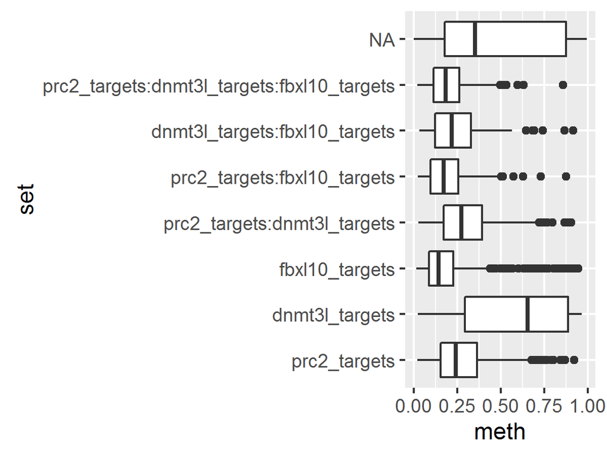

```r
overlaps %>% ggplot(aes(set, meth)) + geom_boxplot() + coord_flip()
```

### 0.19.3 Methylation of MEFs

```r
mef_meth <- data.table::fread("GSE44760_RRBS_Dnmt1WT_KO_CpGs.txt", data.table = F) %>%
  select(chr, start, end=stop, meth = wt_meth_percent) %>%
  makeGRangesFromDataFrame(keep.extra.columns = T)
```

```
##
Read 49.7% of 1790826 rows
Read 94.9% of 1790826 rows
Read 1790826 rows and 7 (of 7) columns from 0.088 GB file in 00:00:04
```

```r
x <- findOverlaps(mef_meth, subset(refseq))

mef_meth_promoters <- cbind(
  queryHits(x) %>% mef_meth[.,] %>% as.data.frame(),
  subjectHits(x) %>% refseq[.,] %>% mcols()
) %>% as.data.frame() %>%
  group_by(gene_name) %>%
  summarize(meth = mean(meth), n_cpg = n()) %>%
  filter(n_cpg >= 5) %>%
  filter(gene_name %in% gene_info$gene_name)

rm(x); rm(mef_meth); gc()
```

```
##           used  (Mb) gc trigger  (Mb) max used  (Mb)
## Ncells 2553519 136.4    3886542 207.6  3886542 207.6
## Vcells 8942299  68.3   30064124 229.4 29995162 228.9
```

```r
x <- venn_with_pval(test = prc2_targets, reference = chipseq_bed_promoter_overlap$ESC_BioDnmt3L_ESC_shGFP, reference_name = "dnmt3l_shGFP", return_all = T)
```

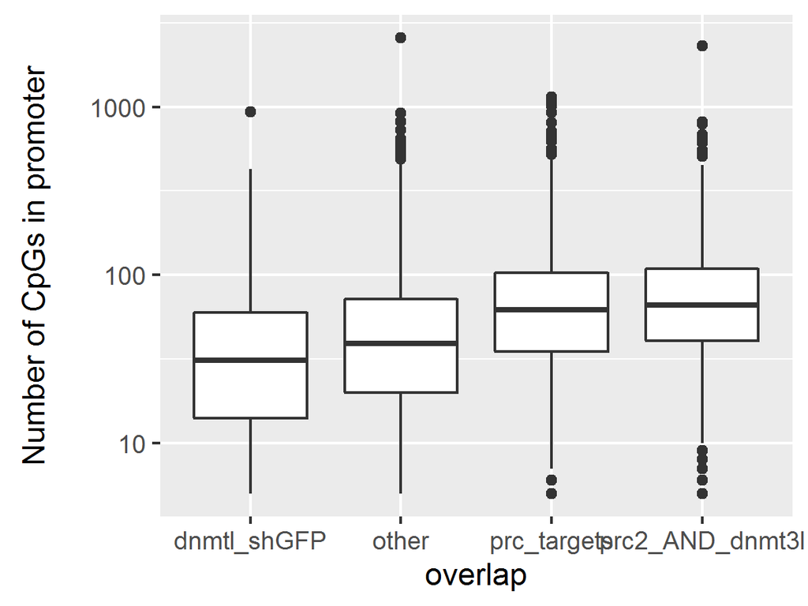

```r
x <- unlist(x) %>% as.data.frame %>% setnames("gene_name") %>%
  mutate(overlap = rownames(.) %>% gsub("[0-9]{1-3}", "", .) %>% as.character(),
         overlap = ifelse(grepl("\\:", overlap), "prc2_AND_dnmt3l", overlap))

left_join(mef_meth_promoters, x) %>%
  # filter(!is.na(overlap)) %>%
  mutate(overlap = ifelse(is.na(overlap), "other", overlap)) %>%
  ggplot(aes(x = overlap, y = n_cpg)) +
  scale_y_log10() +
  ylab("Number of CpGs in promoter\n") +
  geom_boxplot()
```

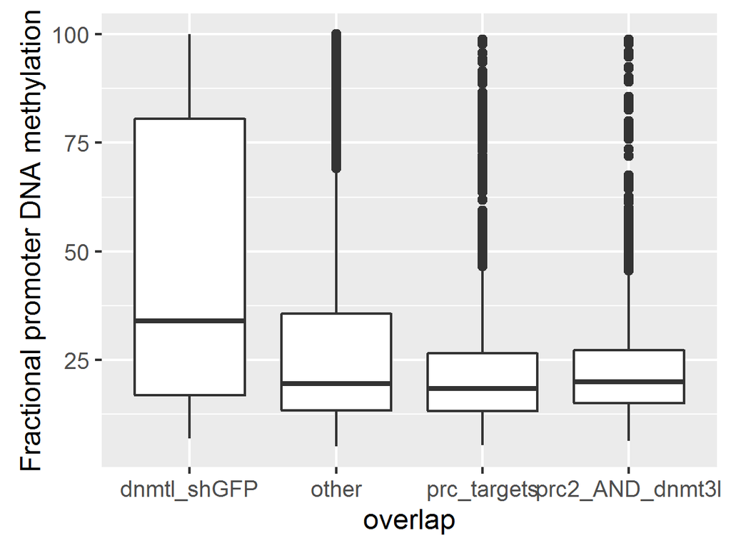

```r
left_join(mef_meth_promoters, x) %>%
  # filter(!is.na(overlap)) %>%
  mutate(overlap = ifelse(is.na(overlap), "other", overlap)) %>%
  ggplot(aes(x = overlap, y = meth)) +
  ylab("Fractional promoter DNA methylation") +
  geom_boxplot()
```

```r
mef_5hmc <- read.table("mef_h5mc.bed.gz") %>% select(chr = V1, start = V2, end = V3) %>% makeGRangesFromDataFrame() %>% find_overlapping_promoters() %>% .$gene_name
```

```r
venn_with_pval(test = mef_5hmc, reference = mef_prc2)
```

[output not shown]

### 0.19.4 Methylation of gene sets

```r
x<-rbind(
  mef_meth_promoters %>%
    left_join(gene_set_query) %>%
    mutate(youngVSold=ifelse(is.na(youngVSold), "Other", youngVSold),
           cell_type = "MEF"),
  esc_meth_overlaps %>%
    left_join(gene_set_query) %>%
    mutate(youngVSold=ifelse(is.na(youngVSold), "Other", youngVSold),
           cell_type = "ESC",
           meth = meth*100)
)
```

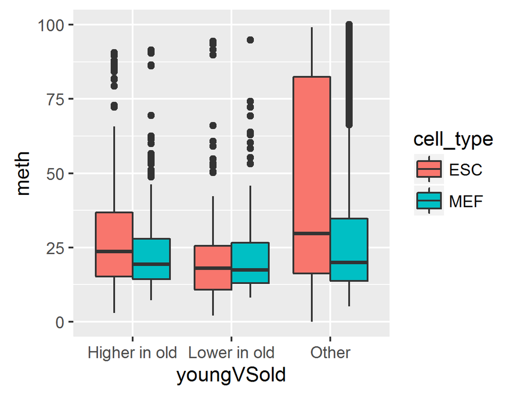

```r
x %>%
  ggplot(aes(youngVSold, meth, fill = cell_type)) +
  geom_boxplot()
```

## 0.20 Chip-seq signals in promoters

```r
file_names <- dir(path = "chipseq_profiles/", pattern = ".gz",full.names = T)

profile_matrix <- file_names %>% lapply(function(x) {
  read.table(x, skip=1, stringsAsFactors = F) %>%
    select(-1,-2,-3,-5,-6) %>%
    inner_join(refseq_to_genename, by = c("V4" = "V1")) %>%
    select(-V4, gene_name = V2) %>% unique %>%
    filter(gene_name %in% gene_info$gene_name)
  })

names(profile_matrix) <- read.table("chipseq_profiles/sample_info.txt") %>% arrange(V1) %>% .$V2
```

```r
# Generate heatmap of profiles

x <- profile_matrix$MEF_H3K27Me3 %>%
  group_by(gene_name) %>%
  summarise_each("mean") %>% as.data.frame %>%
  column_to_rownames("gene_name") %>% as.matrix()

x_mean <- rowMeans(x) %>% sort

# log10(x+1) %>%
x %>%
  .[names(x_mean),] %>%
  # subset(rownames(.) %in% gene_set_query$gene_name) %>%
  heatmap(Rowv = NA, Colv = NA, labRow = NA, labCol = NA)
```

### 0.20.1 TSS profiles

```r
matrix_to_profile <- function(matrix) {
  x <- matrix %>%
    mutate(group = ifelse(gene_name %in% higher_in_old, "Higher in Old",
                          ifelse(gene_name %in% higher_in_young, "Higher in young", "Other"))) %>%
    gather(key = pos, value = signal, -gene_name, -group) %>%
    group_by(group, pos) %>%
    summarize(signal = mean(signal)) %>%
    mutate(pos = gsub("V", "", pos) %>% as.numeric(),
           pos = seq(-5000, 5000, by=100)[pos-5])
}

x <- lapply(profile_matrix, function(x) matrix_to_profile(x))

names(x) <- names(profile_matrix)
```

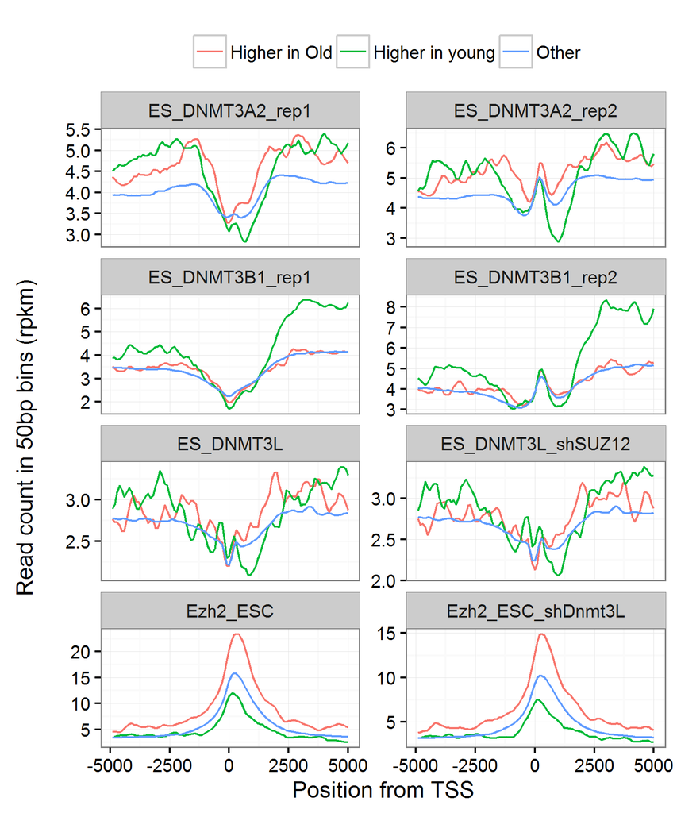

```r
tss_profiles <- bind_rows(x, .id = "mark") %>%
  filter(!grepl("Input|MEF", mark))

tss_profiles %>%
  ggplot(aes(pos, signal, color = group, group = group)) +
  geom_line() +
  facet_wrap(~ mark, scales="free_y", ncol=2) +
  theme_bw() +
  xlab("Position from TSS") +
  ylab("Read count in 50bp bins (rpkm)\n") +
  # theme_bw() +
  theme(legend.position="top", legend.title=element_blank())
```

### 0.20.2 Compare Ezh2 with and without Dnmt3l

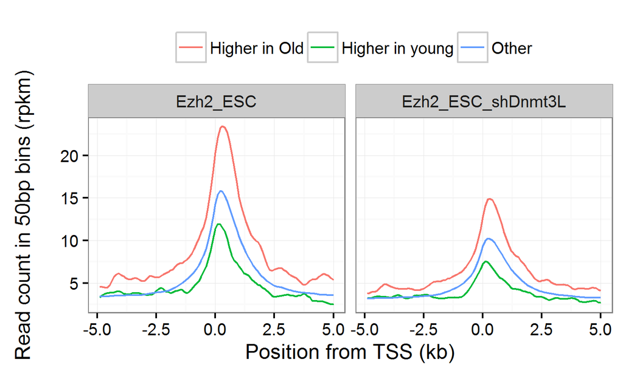

```r
tss_profiles %>% subset(grepl("Ezh2", mark)) %>%
  # mutate(type = ifelse(grepl("\\_sh",  mark), "2_Knockdown", "1_Wildtype")) %>%
  ggplot(aes(pos/1000, signal, color = group)) +
  geom_line() +
  facet_wrap(~ mark, ncol=2) +
  theme_bw() +
  xlab("Position from TSS (kb)") +
  ylab("Read count in 50bp bins (rpkm)\n") +
  # theme_bw() +
  theme(legend.position="top", legend.title=element_blank())
```

### 0.20.3 Compare Dnmt3l with and without Ezh2

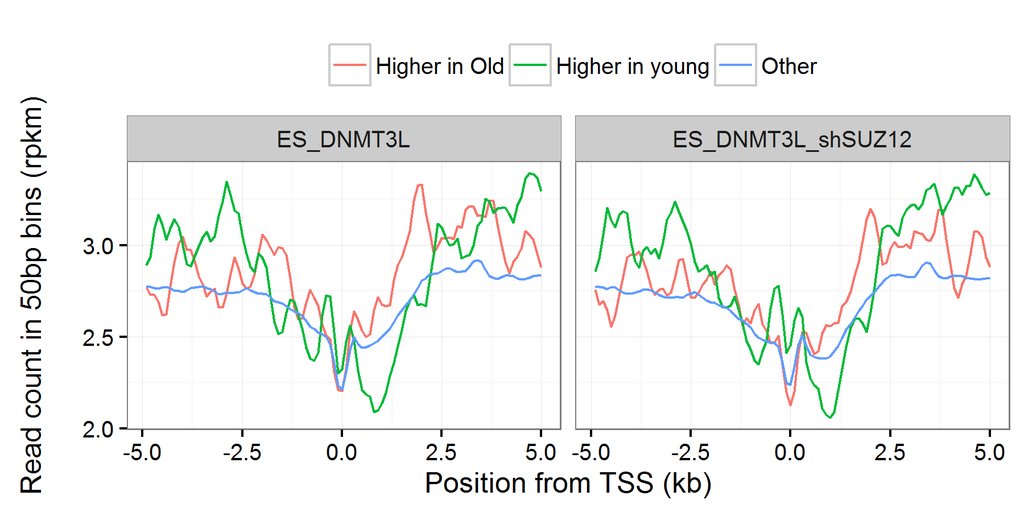

```r
tss_profiles %>% subset(grepl("ES_DNMT3L", mark)) %>%
  # mutate(type = ifelse(grepl("\\_sh",  mark), "2_Knockdown", "1_Wildtype")) %>%
  ggplot(aes(pos/1000, signal, color = group)) +
  geom_line() +
  facet_wrap(~ mark, ncol=2) +
  theme_bw() +
  xlab("Position from TSS (kb)") +
  ylab("Read count in 50bp bins (rpkm)\n") +
  # theme_bw() +
  theme(legend.position="top", legend.title=element_blank())
```

### 0.20.4 Mark2Mark correlation per promoter

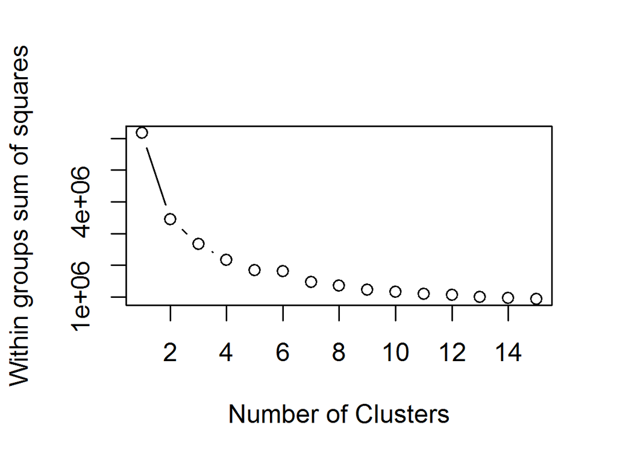

```r
x <- lapply(profile_matrix, function(x) {
  x %>%
    mutate(gene_name = make.unique(gene_name)) %>%
    column_to_rownames("gene_name") %>%
    data.matrix() %>% apply(MARGIN = 1, FUN = mean) %>%
    as.data.frame() %>% setnames("avg_signal") %>% rownames_to_column("gene_id")
})

# x <- c(x, list(MEF_5mc = mef_meth_promoters %>%
                 # select(gene_id = gene_name, avg_signal = meth) %>%
                 # mutate(gene_id = make.unique(gene_id))))

y <- bind_rows(x, .id = "mark") %>% spread(key = mark, value = avg_signal) %>% remove_rownames %>%
  column_to_rownames("gene_id")

optimal_kmeans_clusters(y)
```

```r
z <- kmeans(y, 4)
```

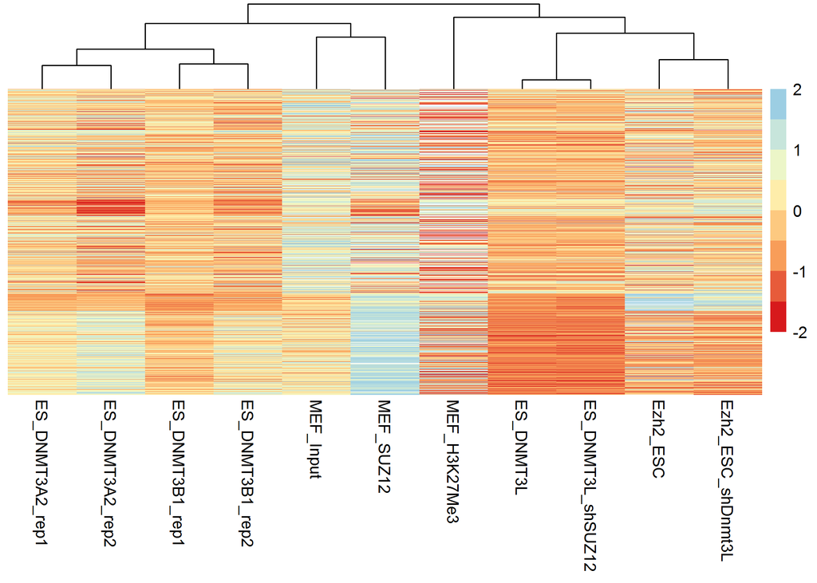

```r
diverg_pallet <- colorRampPalette(brewer.pal(5, name = "RdYlBu"))

log10(data.matrix(y+1)) %>%
  .[names(sort(z$cluster)),] %>%
  # apply(2, rank) %>%
  # apply(1, scale) %>%
  pheatmap(cluster_cols = T, cluster_rows = F, show_rownames=F, breaks = seq(from = -2, to = 2, length.out = 9), color = diverg_pallet(10), scale = "row")
```

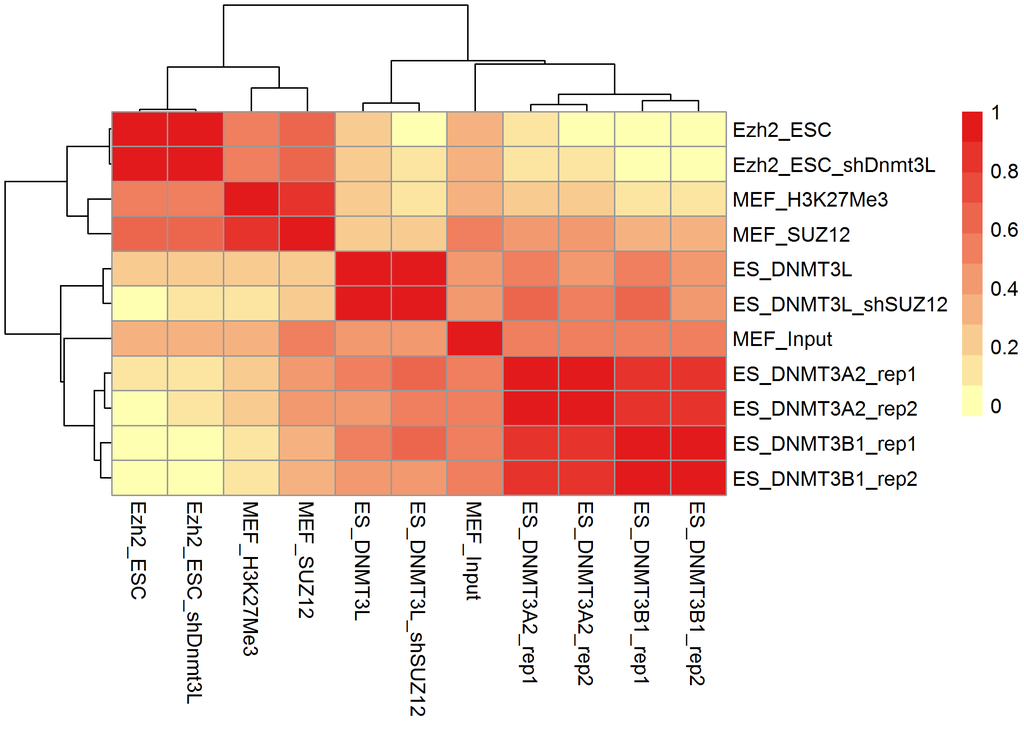

```r
cor(y) %>% pheatmap(color = pallet(10))
```

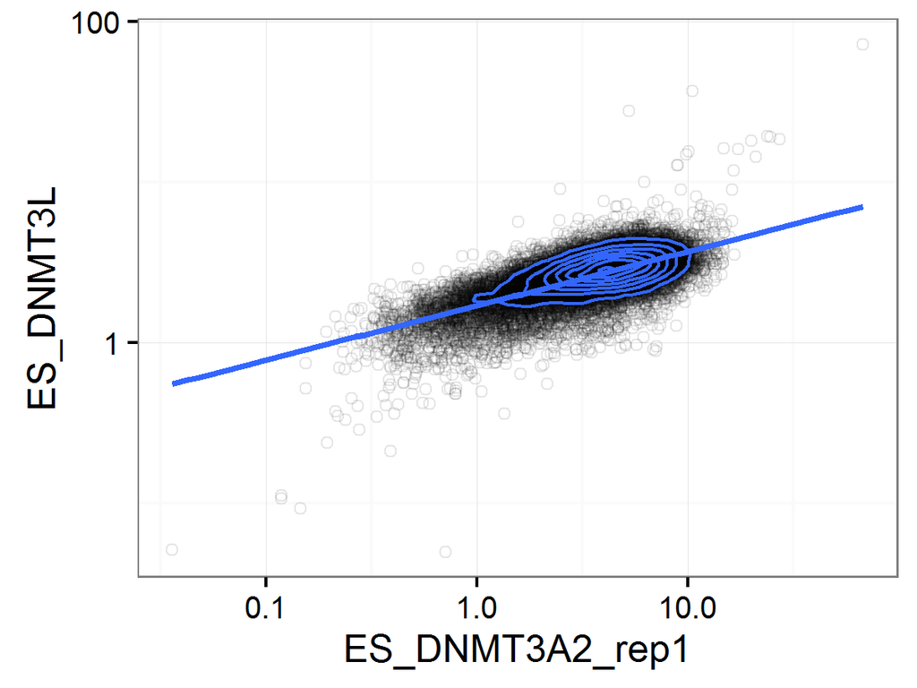

```r
# log10(y+1) %>%
y %>%
  # apply(2, rank) %>%
  as.data.frame() %>%
  ggplot(aes(ES_DNMT3A2_rep1, ES_DNMT3L)) +
  geom_point(alpha=0.1, shape = 1) +
  geom_density2d() +
  geom_smooth(method = "lm") +
  scale_x_log10() +
  scale_y_log10() +
  # scale_color_gradient2(low = "#d8b365", mid = "#f5f5f5", high = "#5ab4ac", midpoint = 0.5) +
  theme_bw()
```

## 0.21 Get negative controls

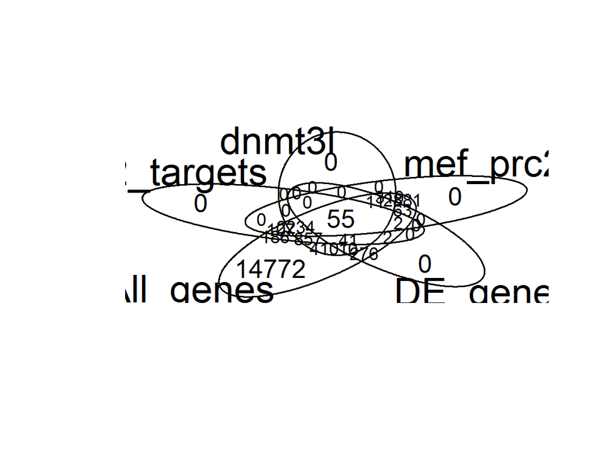

```r
x <- venn(list(
  prc2_targets = prc2_targets,
  dnmt3l = chipseq_bed_promoter_overlap$ESC_Ezh2_ESC_shDnmt3L,
  mef_prc2 = mef_prc2,
  DE_genes = gene_set_query$gene_name,
  All_genes = gene_info$gene_name
))
```

```r
y <-attr(x, "intersections")
```

## 0.22 Misc

### 0.22.1 OVerlap of DNMT3L affected genes with PRC2 targets

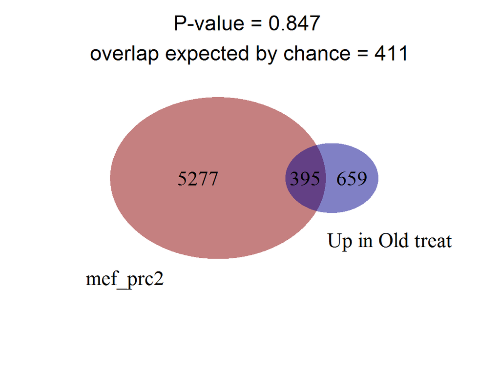

```r
venn_with_pval(mef_prc2, treated_vs_old[[1]], reference_name = "Up in Old treat")
```

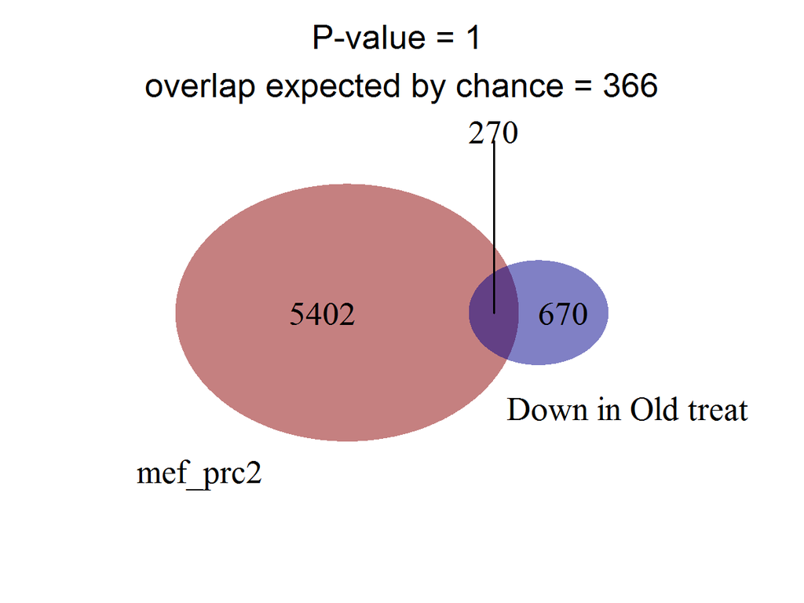

```r
venn_with_pval(mef_prc2, treated_vs_old[[2]], reference_name = "Down in Old treat")
```

### 0.22.2 Identification of Bivalent domains

```r
mef_bivalent <- venn_with_pval(mef_prc2, mef_chipseq_promoter_overlap$ENCODE_MEF_h3k4me3, reference_name = "mef_k4me3", return_overlap = T)
```

[figure not shown]

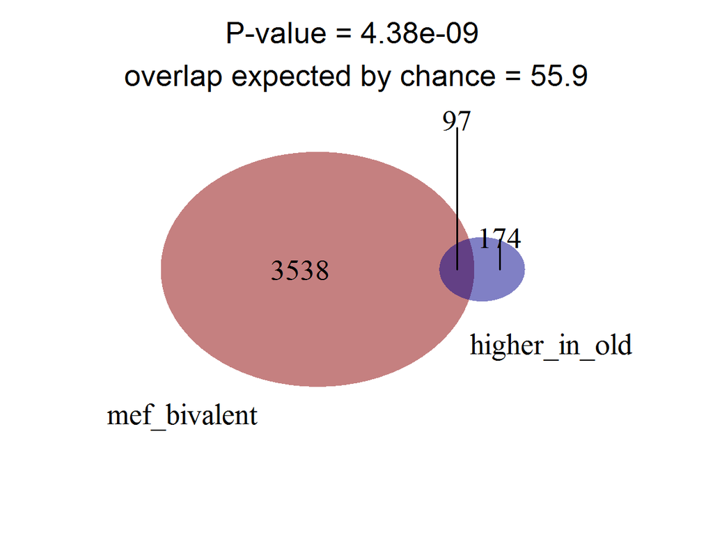

```r
venn_with_pval(mef_bivalent, higher_in_old)
```

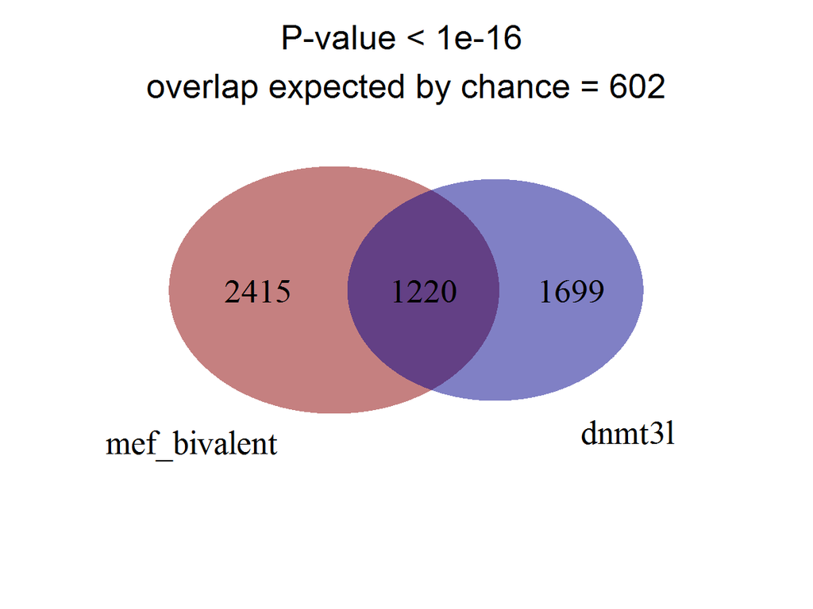

```r
venn_with_pval(mef_bivalent, chipseq_bed_promoter_overlap$ESC_BioDnmt3L_ESC_shGFP, reference_name = "dnmt3l")
```

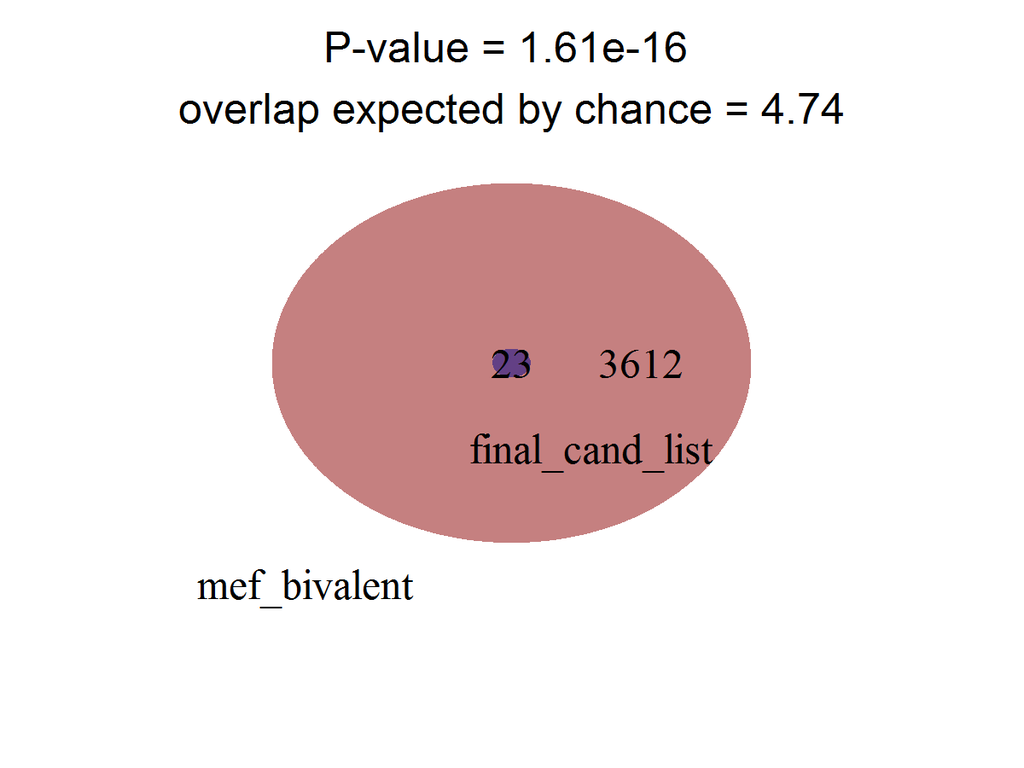

```r
#
# venn(list(
#   mef_h3k4me3 = mef_chipseq_promoter_overlap$ENCODE_MEF_h3k4me3,
#   dnmt3l = chipseq_bed_promoter_overlap$ESC_BioDnmt3L_ESC_shGFP,
#   mef_prc2 = mef_prc2))

venn_with_pval(mef_bivalent, final_cand_list)
```

```r
# venn_with_pval(mef_bivalent, chipseq_bed_promoter_overlap$ESC_BioDnmt3L_ESC_shGFP, reference_name = "ES_dnmt3l")
```

#### 0.22.2.1 Check bivalency with ES not just mef

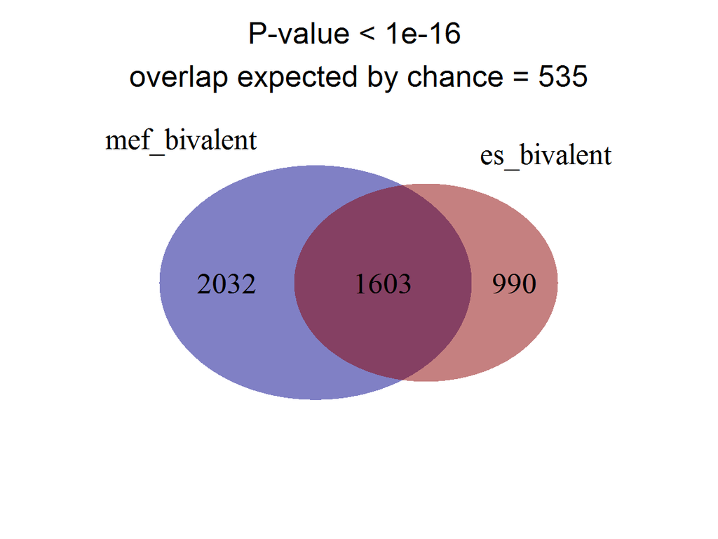

```r
venn_with_pval(es_bivalent, mef_bivalent)
```

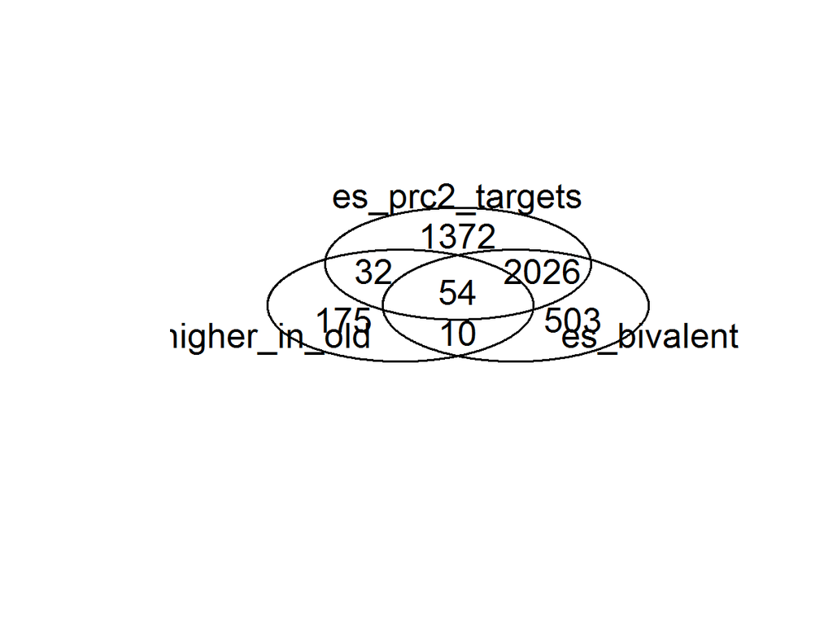

```r
venn(list(higher_in_old=higher_in_old, es_bivalent=es_bivalent, es_prc2_targets=prc2_targets))
```

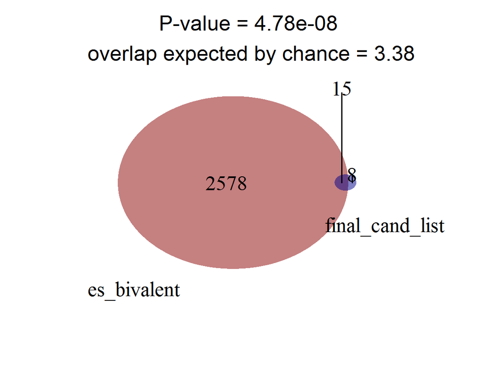

```r
venn_with_pval(es_bivalent, final_cand_list)
```

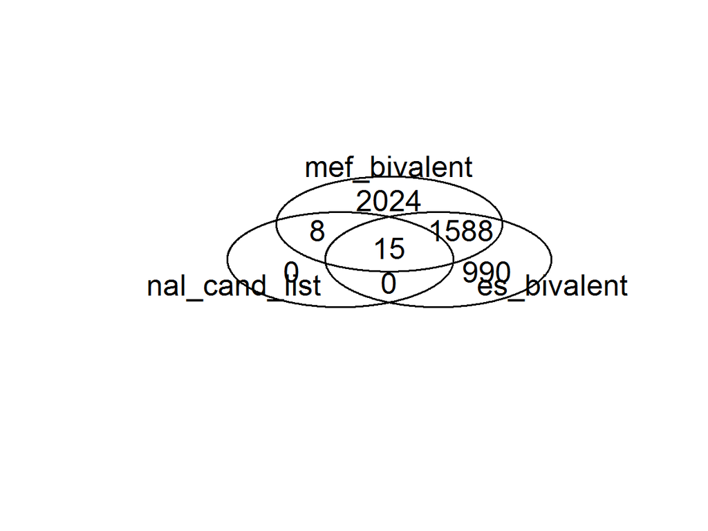

```r
venn(list(final_cand_list=final_cand_list, es_bivalent=es_bivalent, mef_bivalent=mef_bivalent))
```

## 0.23 End

```r
save.image("a_data.RData", compress = F)
system("rm VennDiagram201*")
```